# Final Project Progress Memo

Data Science 2 with R (STAT 301-2)

Author

Zosia Alarr, Chelsea Lu, Ryan Nguyen

## GitHub Repo Link

https://github.com/STAT301-3-2023SP/final-project-weheartr

## Data

The data set we are using came from Kaggle.com: https://www.kaggle.com/datasets/salvatorerastelli/spotify-and-youtube, with data and statistics being pulled from Spotify and YouTube. There are 20,718 observations, each representing a different song. The dataset includes songs from all kinds of genres. The data set consists of 26 variables, which measure different characteristics and statistics of the song. This includes a variety of descriptor variables such as artist, track, album, and description. Additionally, it includes various numeric variables like number of views, comments, tempo, danceability, and loudness, among others. The target variable we will be looking at and trying to predict is the number of likes, which will in turn predict the popularity of a song through a regression problem. The results can help inform artists and songwriters as to what variables can predict the popularity of a song. This can potentially impact the way musical artists write and compose music in order to make them more desirable to a larger audience.

## Issues

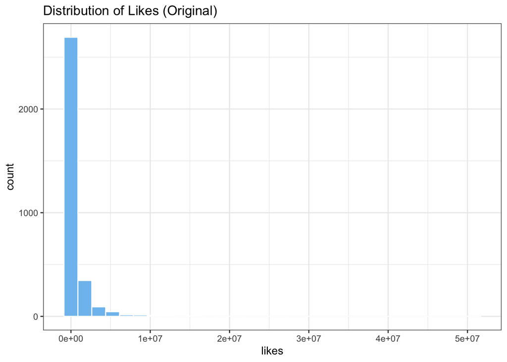

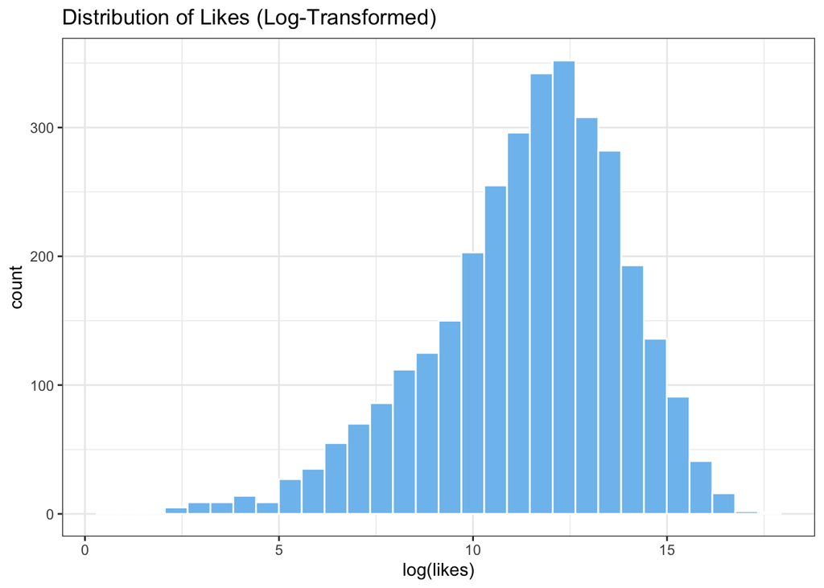

Our initial distribution of our outcome variable `likes` is incredibly right-skewed. After performing a log-transformation, our data is much more centered (although not perfectly centered). It may be beneficial to filter out some of the extreme outliers.

When looking at the original dataset, there were also a lot of id/descriptor variables that were unique to each observation like `url`, `description` and `title`. We deselected these columns, as they are unnecessary to our prediction and won’t be used in any recipes.

## Missingness

[figure not shown]

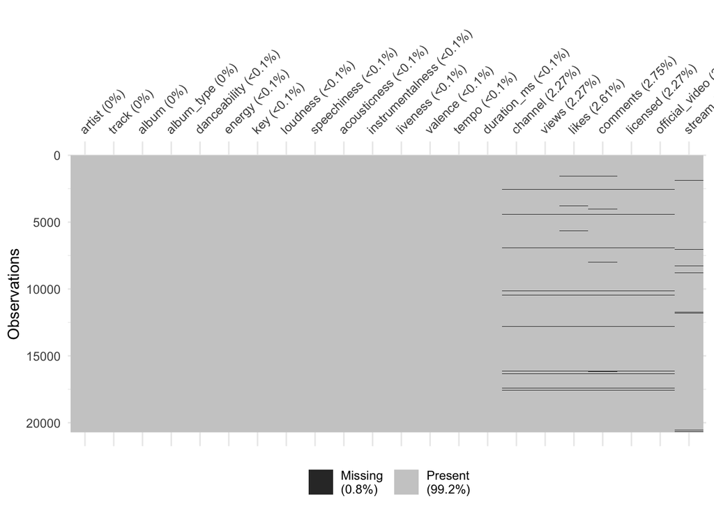

Overall, our data is only missing 0.8%, which is well under the 20% threshold. The variable missing the most observations are `stream` (the number of streams on Spotify), `comments` (number of comments on YouTube), and our outcome variable `likes` (number of likes on YouTube). However, they are all missing under 3%, so we can handle these using imputation steps. We would likely use `step_impute_linear()` or `step_impute_mean()` to handle these observations because they are missing from numeric columns.

## Data Splitting and Resampling Plan

We split the data with a 0.8 proportion, stratifying on our outcome variable `likes`. We folded the data using v-fold cross validation with 5 folds and 3 repeats, for computational purposes since we have over 20,000 observations in the data set.

## Model Comparison and Final Model Evaluation

For comparing model accuracy and selecting the best performing model, we plan on using RMSE to evaluate. Because our outcome variable is numeric, RMSE would be a good metric for comparison between models. We plan on using RMSE to also test the accuracy of the final model.